# DS 202 - Lab 3

Matthew Eisner and Jeffrey Kinard

9/22/2020

```r
library(dplyr)
library(ggplot2)

j_dat <- data.frame(readxl::read_xls('./GSS.xls')) %>%
  rename(year=Gss.year.for.this.respondent) %>%
  rename(happiness=General.happiness) %>%
  rename(religion_raised=Religion.in.which.raised) %>%
  rename(political_party=Political.party.affiliation) %>%
  rename(sex=Respondents.sex) %>%
  rename(school_years=Highest.year.of.school.completed) %>%
  rename(marital_status=Marital.status) %>%
  rename(work_hrs=Number.of.hours.usually.work.a.week) %>%
  rename(id_num=Respondent.id.number) %>%
  rename(ballot=Ballot.used.for.interview)

dat <- readxl::read_xls('./GSS.xls')
colnames(dat) <- c('year', 'happiness', 'religion_raised', 'political_party', 'sex', 'school_years', 'marital_status', 'work_hrs', 'id_num', 'ballot')

dat <- dat %>% mutate(school_years = as.numeric(school_years))
dat <- na.omit(dat)
```

**1. Find the average years of education for the respondents with each political party affiliation. Arrange your output in a meaningful order and print. Describe any patterns you find.**

```r
dat %>% group_by(political_party) %>% summarize(avg_years=mean(school_years), .groups='drop') %>% arrange(avg_years)
```

```
## # A tibble: 10 x 2
##    political_party    avg_years
##    <chr>                  <dbl>
##  1 Don't know              10.9
##  2 No answer               12.3
##  3 Independent             12.3
##  4 Strong democrat         12.5
##  5 Not str democrat        12.6
##  6 Ind,near dem            13.2
##  7 Not str republican      13.3
##  8 Ind,near rep            13.3
##  9 Other party             13.4
## 10 Strong republican       13.4
```

The below bar graph shows the average number of years of education color-coded by political party.

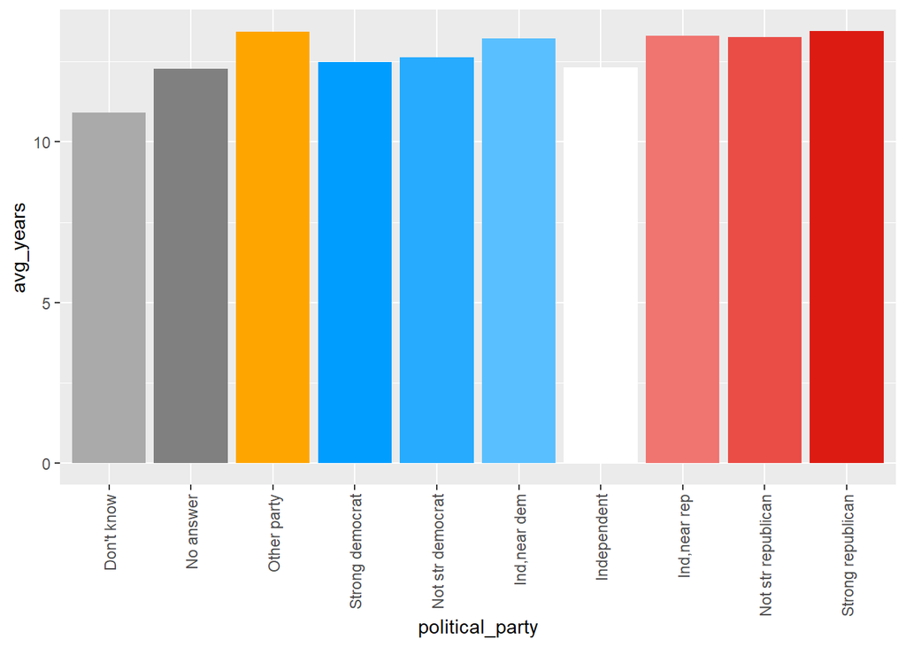

```r
school <- j_dat %>% mutate(school_years = as.numeric(school_years)) %>%
  filter(!is.na(school_years)) %>%
  select(one_of(c("school_years", "political_party")))
t <- school %>%
  group_by(political_party) %>%
  summarise(avg_years=mean(school_years))
x <- c("Don't know", "No answer", "Other party",
       "Strong democrat", "Not str democrat", "Ind,near dem",
       "Independent", "Ind,near rep", "Not str republican",
       "Strong republican")
t <- t %>% slice(match(x, political_party))
t$political_party <- factor(t$political_party, levels=x)
cbPalette <- c("#aaaaaa", "#808080", "#ffa500", "#009dff", "#26abff", "#59bfff", "#ffffff", "#f07470", "#ea4c46", "#dc1c13")
t %>% ggplot(aes(x=political_party, y=avg_years, fill=political_party)) +
  geom_bar(stat="identity") +
  theme(legend.position="none") +
  scale_fill_manual(values=cbPalette) +
  theme(axis.text.x = element_text(angle = 90, vjust = 0.5, hjust=1))
```

**2. Create a single data frame containing records for the better educated respondents in each political party affiliation. A “better educated” respondent is someone who has strictly more years of education than the median in the same party affiliation. Print the structure of the data frame.**

```r
educ <- dat %>% group_by(political_party) %>% filter(school_years > median(school_years))
str(educ)
```

```
## tibble [27,840 x 10] (S3: grouped_df/tbl_df/tbl/data.frame)
##  $ year           : num [1:27840] 1972 1972 1972 1972 1972 ...
##  $ happiness      : chr [1:27840] "Not too happy" "Not too happy" "Pretty happy" "Not too happy" ...
##  $ religion_raised: chr [1:27840] "Not applicable" "Not applicable" "Not applicable" "Not applicable" ...
##  $ political_party: chr [1:27840] "Ind,near dem" "Not str democrat" "Ind,near dem" "Ind,near dem" ...
##  $ sex            : chr [1:27840] "Female" "Female" "Male" "Male" ...
##  $ school_years   : num [1:27840] 16 17 14 16 13 14 14 17 14 16 ...
##  $ marital_status : chr [1:27840] "Never married" "Married" "Never married" "Never married" ...
##  $ work_hrs       : chr [1:27840] "Not applicable" "Not applicable" "Not applicable" "Not applicable" ...
##  $ id_num         : num [1:27840] 1 4 6 8 11 16 17 19 20 25 ...
##  $ ballot         : chr [1:27840] "Not applicable" "Not applicable" "Not applicable" "Not applicable" ...
##  - attr(*, "groups")= tibble [10 x 2] (S3: tbl_df/tbl/data.frame)
##   ..$ political_party: chr [1:10] "Don't know" "Ind,near dem" "Ind,near rep" "Independent" ...
##   ..$ .rows          : list<int> [1:10]
##   .. ..$ : int [1:5] 837 1083 1137 1262 23661
##   .. ..$ : int [1:3257] 1 3 4 8 16 19 27 35 41 47 ...
##   .. ..$ : int [1:2456] 7 9 11 21 43 53 56 58 59 68 ...
##   .. ..$ : int [1:3852] 23 29 45 48 49 57 62 78 79 102 ...
##   .. ..$ : int [1:148] 299 519 689 897 1007 1102 1191 1482 1513 1648 ...
##   .. ..$ : int [1:5692] 2 13 15 25 28 31 36 38 44 46 ...
##   .. ..$ : int [1:4322] 14 18 20 24 30 33 42 52 65 71 ...
##   .. ..$ : int [1:520] 22 26 61 89 99 111 151 154 192 376 ...
##   .. ..$ : int [1:4537] 5 6 12 17 37 39 40 74 75 76 ...
##   .. ..$ : int [1:3051] 10 32 34 50 51 64 66 88 100 127 ...
##   .. ..@ ptype: int(0)
##   ..- attr(*, ".drop")= logi TRUE
```

**3. How is the happiness of a respondent related to his/her marriage status? Define that a person is happy if the response to question is “Very happy” or “Pretty happy”.**

The only groups that had over 50% of respondents answer that they were happy were those who identified as divorced, never married, separated, or widowed. Those who were married or did not answer were the only groups where less than 50% of responses were happy.

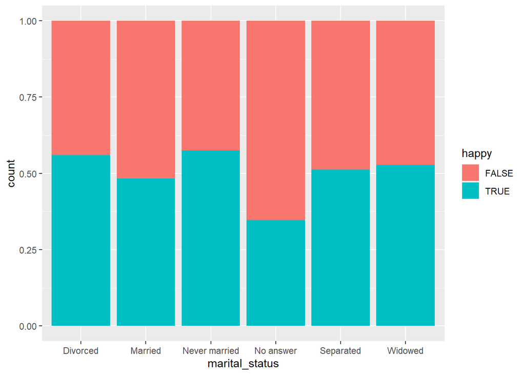

```r
dat1 <- mutate(dat, happy = ifelse(happiness == 'Very Happy' | happiness == 'Pretty happy', TRUE, FALSE))
ggplot(dat1, aes(x=marital_status, fill=happy)) + geom_bar(position='fill')
```

**4. Does party affiliation affect the relationship you found in the last question?**

The below charts show that political party choice can affect the happiness levels slightly, but the numbers don’t vary greatly.

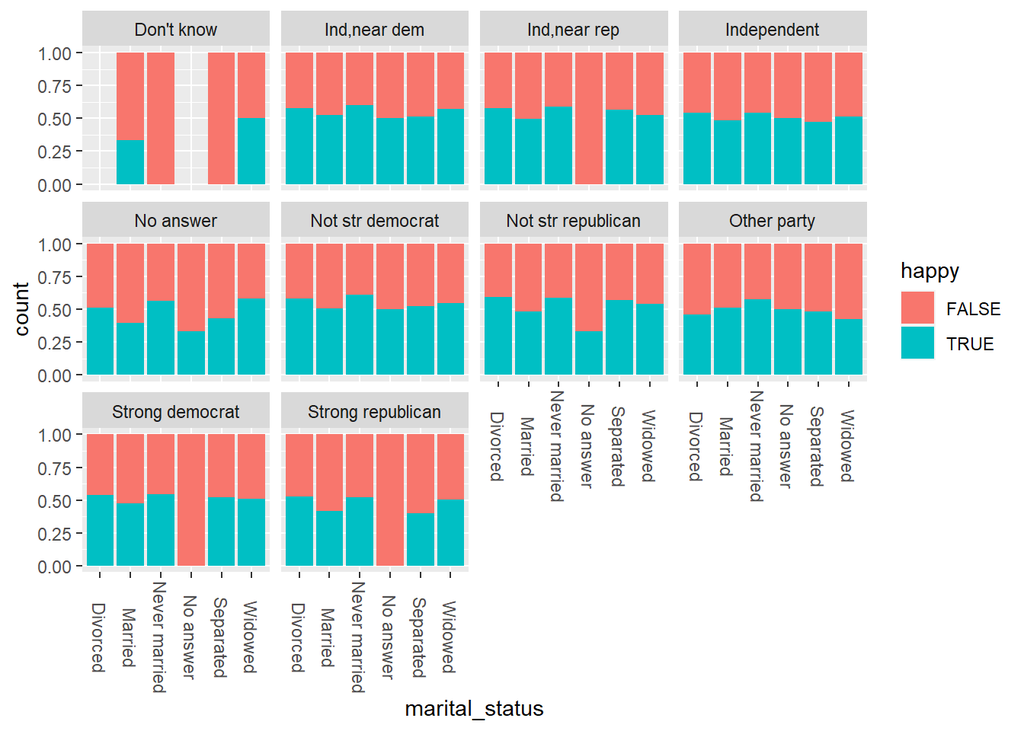

```r
ggplot(dat1, aes(x=marital_status, fill=happy)) + geom_bar(position='fill') + facet_wrap(~political_party) + theme(axis.text.x=element_text(angle =- 90, vjust = 0.5))
```

**5. How is marital status related to the education of a respondent? What are possible reasons accounting for the patterns you see?**

The below boxplots show the breakdown of each marital status according to the number of years spent in school.

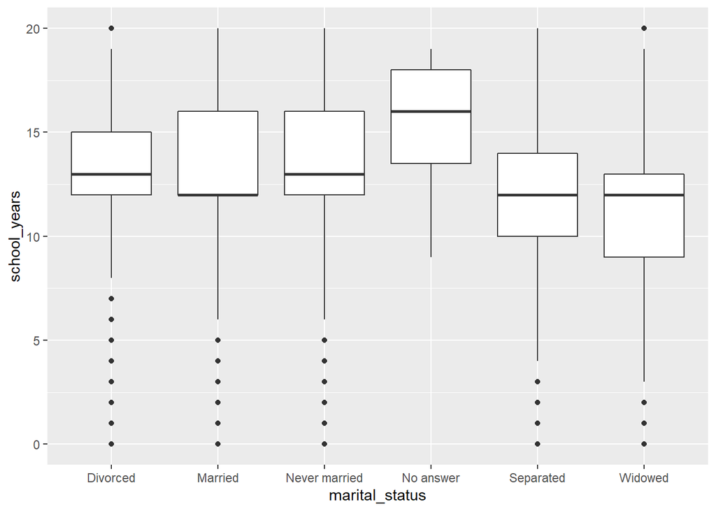

```r
ggplot(dat, aes(x=marital_status, y=school_years)) + geom_boxplot()
```

In the table below, we see that widowed and separated respondents sit below 12 years of education on average. Married, divorced, and never married respondents average around 13 years of education, and those who did not answer averaged around 15.5 years of education.

```r
dat %>% group_by(marital_status) %>% summarize(avg_years=mean(school_years), .groups='drop') %>% arrange(avg_years)
```

```
## # A tibble: 6 x 2
##   marital_status avg_years
##   <chr>              <dbl>
## 1 Widowed             11.2
## 2 Separated           11.9
## 3 Married             13.0
## 4 Divorced            13.1
## 5 Never married       13.4
## 6 No answer           15.5
```

Below, the average number of years of education by marital status is shown. This plot shows that, on average, people who were never married have the most years of education. It also shows that widowed respondents had the least number of years of education, on average.

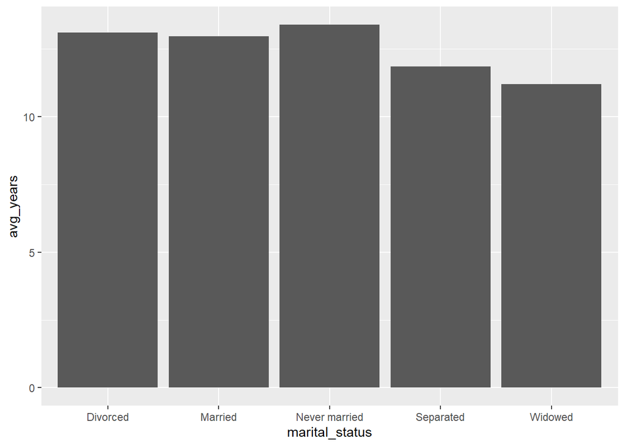

```r
marital <- j_dat %>% select(one_of(c("marital_status", "school_years"))) %>%
  mutate(school_years = as.numeric(school_years)) %>%
  filter(!is.na(school_years) & marital_status != "No answer") %>%
  group_by(marital_status) %>%
  summarise(avg_years=mean(school_years))
marital %>% ggplot(aes(x=marital_status, y=avg_years)) + geom_bar(stat="identity")
```

One reason that people who are never married have a higher average education could be that they had less time to date since they were in school so long. It could also be due to the fact that respondents with a higher education did not have a family with a significant other, so more money could be spent on education.

**6. Explore two more interesting questions, and answer those questions using the GSS data.**

There are two questions that we will aim to answer:  
- Relationship between amount of time spent in school vs. amount of hours worked per week  
- How religion compares with political party choice, and how education further affects this relationship

There is no strong relationship between amount of time spent in school and amount of hours worked in a week. This is because the scatterplot shows no obvious form or direction as the points are widely spread. In addition, the linear regression line is nearly horizontal, further displaying weak correlation between the variables.

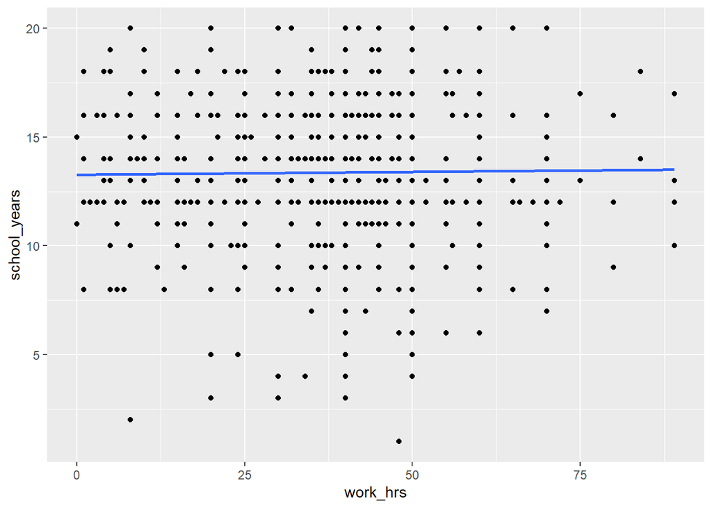

```r
dat <- dat %>% mutate(work_hrs = as.numeric(work_hrs))
dat <- na.omit(dat)

ggplot(dat, aes(x=work_hrs, y=school_years)) + geom_point() + geom_smooth(method = "lm", se=FALSE)
```

```r
religion <- j_dat %>% select(one_of(c("religion_raised", "school_years", "political_party")))  %>%
  mutate(school_years = as.numeric(school_years)) %>%
  filter(!is.na(school_years) & political_party != "No answer") %>%
  filter(religion_raised != "Don't know" & religion_raised != "No answer") %>%
  filter(religion_raised != "Not applicable") %>%
  group_by(religion_raised, political_party) %>%
  summarise(avg_years=mean(school_years))
religion_count <- j_dat %>% select(one_of(c("religion_raised", "school_years", "political_party")))  %>%
  mutate(school_years = as.numeric(school_years)) %>%
  filter(!is.na(school_years) & political_party != "No answer") %>%
  filter(religion_raised != "Don't know" & religion_raised != "No answer") %>%
  filter(religion_raised != "Not applicable") %>%
  group_by(religion_raised, political_party) %>%
  summarise(religion_count=n())
religion$religion_count <- religion_count$religion_count
x <- c("Don't know","No answer", "Other party",
       "Strong democrat", "Not str democrat", "Ind,near dem",
       "Independent", "Ind,near rep", "Not str republican",
       "Strong republican")
religion$political_party <- factor(religion$political_party, levels=x)
cbPalette <- c("#808080", "#ffa500", "#009dff", "#26abff", "#59bfff", "#ffffff",
               "#f07470", "#ea4c46", "#dc1c13")
```

The first plot below shows the number of respondents for each political party by religion. It is interesting to see how all of the major world religions lean more towards the democratic side. Typically, republican ideologies line up with conservative religious beliefs, so to see this trend is very surprising.

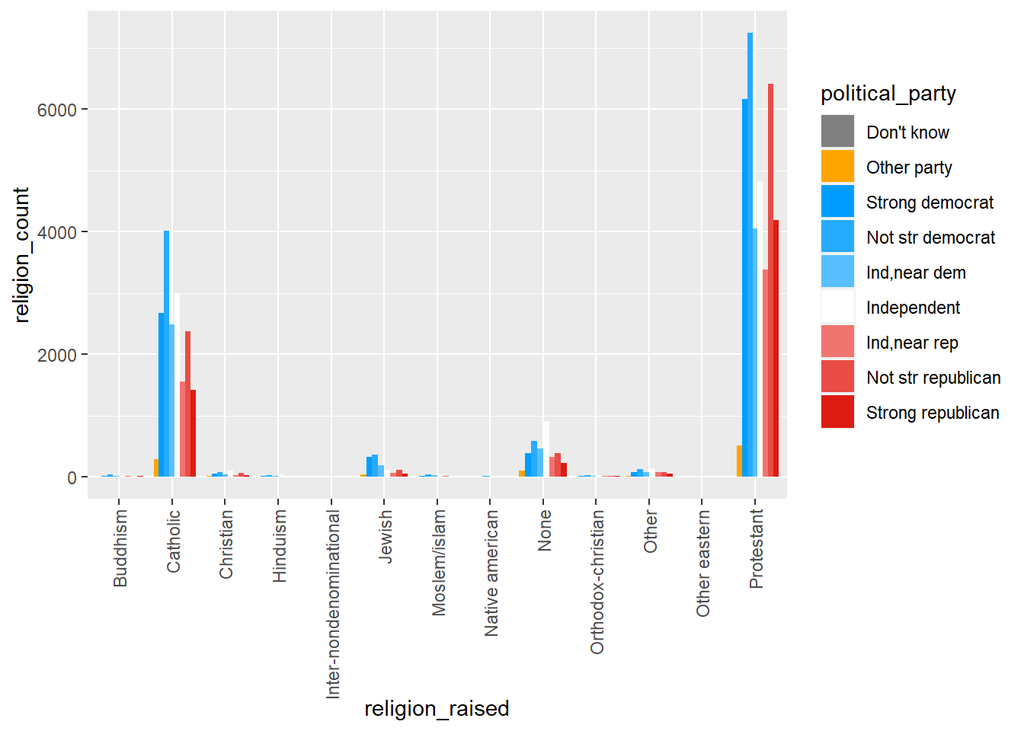

```r
religion %>% ggplot(aes(x=religion_raised, y=religion_count, fill=political_party)) +
  geom_bar(stat="identity", position="dodge") +
  scale_fill_manual(values=cbPalette) +
  theme(axis.text.x = element_text(angle = 90, vjust = 0.5, hjust=1))
```

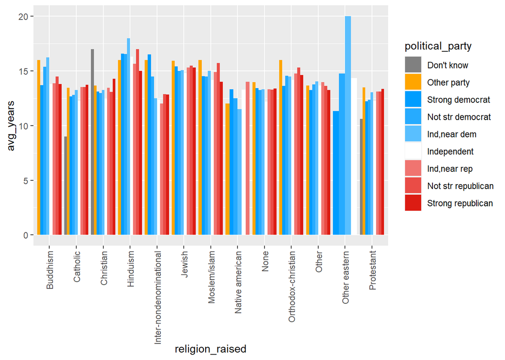

```r
religion %>% ggplot(aes(x=religion_raised, y=avg_years, fill=political_party)) +
  geom_bar(stat="identity", position="dodge") +
  scale_fill_manual(values=cbPalette) +
  theme(axis.text.x = element_text(angle = 90, vjust = 0.5, hjust=1))
```